# TP2: Pandas, data analysis library

# KONDO Godson Leopold Jr.

```python
import numpy as np
import seaborn as sns
import pandas as pd
import matplotlib.pyplot as plt
%matplotlib notebook
```

# Short intro into pandas

```python
data = pd.read_csv("bookings.csv")
```

```python
data.head(5) # print first 5 entries of the dataset
```

|  | hotel | is_canceled | lead_time | arrival_date_year | arrival_date_month | arrival_date_week_number | arrival_date_day_of_month | stays_in_weekend_nights | stays_in_week_nights | adults | ... | deposit_type | agent | company | days_in_waiting_list | customer_type | adr | required_car_parking_spaces | total_of_special_requests | reservation_status | reservation_status_date |
| --- | --- | --- | --- | --- | --- | --- | --- | --- | --- | --- | --- | --- | --- | --- | --- | --- | --- | --- | --- | --- | --- |
| 0 | Resort Hotel | 0 | 342 | 2015 | July | 27 | 1 | 0 | 0 | 2 | ... | No Deposit | NaN | NaN | 0 | Transient | 0.0 | 0 | 0 | Check-Out | 2015-07-01 |
| 1 | Resort Hotel | 0 | 737 | 2015 | July | 27 | 1 | 0 | 0 | 2 | ... | No Deposit | NaN | NaN | 0 | Transient | 0.0 | 0 | 0 | Check-Out | 2015-07-01 |
| 2 | Resort Hotel | 0 | 7 | 2015 | July | 27 | 1 | 0 | 1 | 1 | ... | No Deposit | NaN | NaN | 0 | Transient | 75.0 | 0 | 0 | Check-Out | 2015-07-02 |
| 3 | Resort Hotel | 0 | 13 | 2015 | July | 27 | 1 | 0 | 1 | 1 | ... | No Deposit | 304.0 | NaN | 0 | Transient | 75.0 | 0 | 0 | Check-Out | 2015-07-02 |
| 4 | Resort Hotel | 0 | 14 | 2015 | July | 27 | 1 | 0 | 2 | 2 | ... | No Deposit | 240.0 | NaN | 0 | Transient | 98.0 | 0 | 1 | Check-Out | 2015-07-03 |

5 rows × 32 columns

```python
data.columns # print column names
```

```
Index(['hotel', 'is_canceled', 'lead_time', 'arrival_date_year',
       'arrival_date_month', 'arrival_date_week_number',
       'arrival_date_day_of_month', 'stays_in_weekend_nights',
       'stays_in_week_nights', 'adults', 'children', 'babies', 'meal',
       'country', 'market_segment', 'distribution_channel',
       'is_repeated_guest', 'previous_cancellations',
       'previous_bookings_not_canceled', 'reserved_room_type',
       'assigned_room_type', 'booking_changes', 'deposit_type', 'agent',
       'company', 'days_in_waiting_list', 'customer_type', 'adr',
       'required_car_parking_spaces', 'total_of_special_requests',
       'reservation_status', 'reservation_status_date'],
      dtype='object')
```

This dataset contains information about bookings of two hotels. Hotel 1 is a resort hotel and Hotel 2 is a city hotel in Portugal. The dataset was released by https://www.sciencedirect.com/science/article/pii/S2352340918315191.

There are 32 columns in this dataset:

1. **hotel** -- one of the two hotels
2. **is_canceled** -- Value indicating if the booking was canceled (1) or not (0)
3. **lead_time** -- Number of days that elapsed between the entering date of the booking into the PMS and the arrival date
4. ....

For the full description of each column please see: https://www.kaggle.com/jessemostipak/hotel-booking-demand

```python
data['country'] # we can also print each column of the dataset
```

```
0         PRT
1         PRT
2         GBR
3         GBR
4         GBR
         ...
119385    BEL
119386    FRA
119387    DEU
119388    GBR
119389    DEU
Name: country, Length: 119390, dtype: object
```

```python
data['country'].unique() # list all unique values in the column
```

```
array(['PRT', 'GBR', 'USA', 'ESP', 'IRL', 'FRA', nan, 'ROU', 'NOR', 'OMN',
       'ARG', 'POL', 'DEU', 'BEL', 'CHE', 'CN', 'GRC', 'ITA', 'NLD',
       'DNK', 'RUS', 'SWE', 'AUS', 'EST', 'CZE', 'BRA', 'FIN', 'MOZ',
       'BWA', 'LUX', 'SVN', 'ALB', 'IND', 'CHN', 'MEX', 'MAR', 'UKR',
       'SMR', 'LVA', 'PRI', 'SRB', 'CHL', 'AUT', 'BLR', 'LTU', 'TUR',
       'ZAF', 'AGO', 'ISR', 'CYM', 'ZMB', 'CPV', 'ZWE', 'DZA', 'KOR',
       'CRI', 'HUN', 'ARE', 'TUN', 'JAM', 'HRV', 'HKG', 'IRN', 'GEO',
       'AND', 'GIB', 'URY', 'JEY', 'CAF', 'CYP', 'COL', 'GGY', 'KWT',
       'NGA', 'MDV', 'VEN', 'SVK', 'FJI', 'KAZ', 'PAK', 'IDN', 'LBN',
       'PHL', 'SEN', 'SYC', 'AZE', 'BHR', 'NZL', 'THA', 'DOM', 'MKD',
       'MYS', 'ARM', 'JPN', 'LKA', 'CUB', 'CMR', 'BIH', 'MUS', 'COM',
       'SUR', 'UGA', 'BGR', 'CIV', 'JOR', 'SYR', 'SGP', 'BDI', 'SAU',
       'VNM', 'PLW', 'QAT', 'EGY', 'PER', 'MLT', 'MWI', 'ECU', 'MDG',
       'ISL', 'UZB', 'NPL', 'BHS', 'MAC', 'TGO', 'TWN', 'DJI', 'STP',
       'KNA', 'ETH', 'IRQ', 'HND', 'RWA', 'KHM', 'MCO', 'BGD', 'IMN',
       'TJK', 'NIC', 'BEN', 'VGB', 'TZA', 'GAB', 'GHA', 'TMP', 'GLP',
       'KEN', 'LIE', 'GNB', 'MNE', 'UMI', 'MYT', 'FRO', 'MMR', 'PAN',
       'BFA', 'LBY', 'MLI', 'NAM', 'BOL', 'PRY', 'BRB', 'ABW', 'AIA',
       'SLV', 'DMA', 'PYF', 'GUY', 'LCA', 'ATA', 'GTM', 'ASM', 'MRT',
       'NCL', 'KIR', 'SDN', 'ATF', 'SLE', 'LAO'], dtype=object)
```

```python
data.count()
```

```
hotel                             119390
is_canceled                       119390
lead_time                         119390
arrival_date_year                 119390
arrival_date_month                119390
arrival_date_week_number          119390
arrival_date_day_of_month         119390
stays_in_weekend_nights           119390
stays_in_week_nights              119390
adults                            119390
children                          119386
babies                            119390
meal                              119390
country                           118902
market_segment                    119390
distribution_channel              119390
is_repeated_guest                 119390
previous_cancellations            119390
previous_bookings_not_canceled    119390
reserved_room_type                119390
assigned_room_type                119390
booking_changes                   119390
deposit_type                      119390
agent                             103050
company                             6797
days_in_waiting_list              119390
customer_type                     119390
adr                               119390
required_car_parking_spaces       119390
total_of_special_requests         119390
reservation_status                119390
reservation_status_date           119390
dtype: int64
```

```python
data["required_car_parking_spaces"].unique()
```

```
array([0, 1, 2, 8, 3])
```

This dataset contains 119390 different reservations. Some of the reservations have missing values.

```python
data.values # A data frame can be converted into a numpy array by calling the values attribute:
```

```
array([['Resort Hotel', 0, 342, ..., 0, 'Check-Out', '2015-07-01'],
       ['Resort Hotel', 0, 737, ..., 0, 'Check-Out', '2015-07-01'],
       ['Resort Hotel', 0, 7, ..., 0, 'Check-Out', '2015-07-02'],
       ...,
       ['City Hotel', 0, 34, ..., 4, 'Check-Out', '2017-09-07'],
       ['City Hotel', 0, 109, ..., 0, 'Check-Out', '2017-09-07'],
       ['City Hotel', 0, 205, ..., 2, 'Check-Out', '2017-09-07']],
      dtype=object)
```

However this array cannot be directly fed to a scikit-learn model.

1. the values are heterogeneous (strings for categories, integers, and floating point numbers)
2. some attribute values are missing

# Predicting cancellation: Part I -- visualization

**Our goals** The goal of this part is to provide few examples of visualization combining `pandas`, `matplotlib`, `seaborn`.

We will look at a very natural and practical task -- predicting cancellation of a given reservation. Of course, the first instinct of the modern 'ML practitioner' is to throw all the data to some neural net and perform bunch of fine-tuning. There are really a lot of problems with such an approach. As a general rule of thumbs: explore your data before building ML pipelines! It is always more interesting to investigate the data and find human-interpretable patterns.

Pandas allows to manipulate the dataset in a very convenient manner. Those familiar with SQL will certainly appreciate it!

As the first visualization task let us understand which monthes have the most amount of cancellations. We start by creating a new dataset that contains the information that we would like to plot.

```python
'''
 We create two datasets for each hotel .groupby("arrival_date_month") will group observations by the month
 and .count() function will simply count the amount of reservations for each month
'''
n_reserv_H1 = data.loc[(data["hotel"] == "Resort Hotel")].groupby("arrival_date_month")["hotel"].count()
n_cancel_H1 = data.loc[(data["hotel"] == "Resort Hotel")].groupby("arrival_date_month")["is_canceled"].sum()

# same thing we do for the second hotel
n_reserv_H2 = data.loc[(data["hotel"] == "City Hotel")].groupby("arrival_date_month")["hotel"].count()
n_cancel_H2 = data.loc[(data["hotel"] == "City Hotel")].groupby("arrival_date_month")["is_canceled"].sum()
```

```python
n_reserv_H1.head() # again we can have a look at the top 5 entries
```

```
arrival_date_month
April       3609
August      4894
December    2648
February    3103
January     2193
Name: hotel, dtype: int64
```

```python
n_reserv_H1['April'] # number of reservation for Resort Hotel for April
```

```
3609
```

```python
n_cancel_H1['April'] # number of cancelled reservations for Resort Hotel for April
```

```
1059
```

```python
# finally, we gather everything together


data_visualH1 = pd.DataFrame({"hotel": "Resort Hotel",
                                "month": list(n_reserv_H1.index),
                                "n_booking": list(n_reserv_H1.values),
                                "n_cancel": list(n_cancel_H1.values)})
data_visualH2 = pd.DataFrame({"hotel": "City Hotel",
                                "month": list(n_reserv_H2.index),
                                "n_booking": list(n_reserv_H2.values),
                                "n_cancel": list(n_cancel_H2.values)})
data_visual = pd.concat([data_visualH1, data_visualH2], ignore_index=True)

# notice how easy it is to add a new column. We simply write the following
data_visual["percent_cancel"] = data_visual["n_cancel"] / data_visual["n_booking"] * 100 # percent of cancelations
```

```python
data_visual.head(24) # our final dataset
```

|  | hotel | month | n_booking | n_cancel | percent_cancel |
| --- | --- | --- | --- | --- | --- |
| 0 | Resort Hotel | April | 3609 | 1059 | 29.343308 |
| 1 | Resort Hotel | August | 4894 | 1637 | 33.449121 |
| 2 | Resort Hotel | December | 2648 | 631 | 23.829305 |
| 3 | Resort Hotel | February | 3103 | 795 | 25.620367 |
| 4 | Resort Hotel | January | 2193 | 325 | 14.819881 |
| 5 | Resort Hotel | July | 4573 | 1436 | 31.401706 |
| 6 | Resort Hotel | June | 3045 | 1007 | 33.070608 |
| 7 | Resort Hotel | March | 3336 | 763 | 22.871703 |
| 8 | Resort Hotel | May | 3559 | 1024 | 28.772127 |
| 9 | Resort Hotel | November | 2437 | 461 | 18.916701 |
| 10 | Resort Hotel | October | 3555 | 978 | 27.510549 |
| 11 | Resort Hotel | September | 3108 | 1006 | 32.368082 |
| 12 | City Hotel | April | 7480 | 3465 | 46.323529 |
| 13 | City Hotel | August | 8983 | 3602 | 40.097963 |
| 14 | City Hotel | December | 4132 | 1740 | 42.110358 |
| 15 | City Hotel | February | 4965 | 1901 | 38.288016 |
| 16 | City Hotel | January | 3736 | 1482 | 39.668094 |
| 17 | City Hotel | July | 8088 | 3306 | 40.875371 |
| 18 | City Hotel | June | 7894 | 3528 | 44.692171 |
| 19 | City Hotel | March | 6458 | 2386 | 36.946423 |
| 20 | City Hotel | May | 8232 | 3653 | 44.375607 |
| 21 | City Hotel | November | 4357 | 1661 | 38.122561 |
| 22 | City Hotel | October | 7605 | 3268 | 42.971729 |
| 23 | City Hotel | September | 7400 | 3110 | 42.027027 |

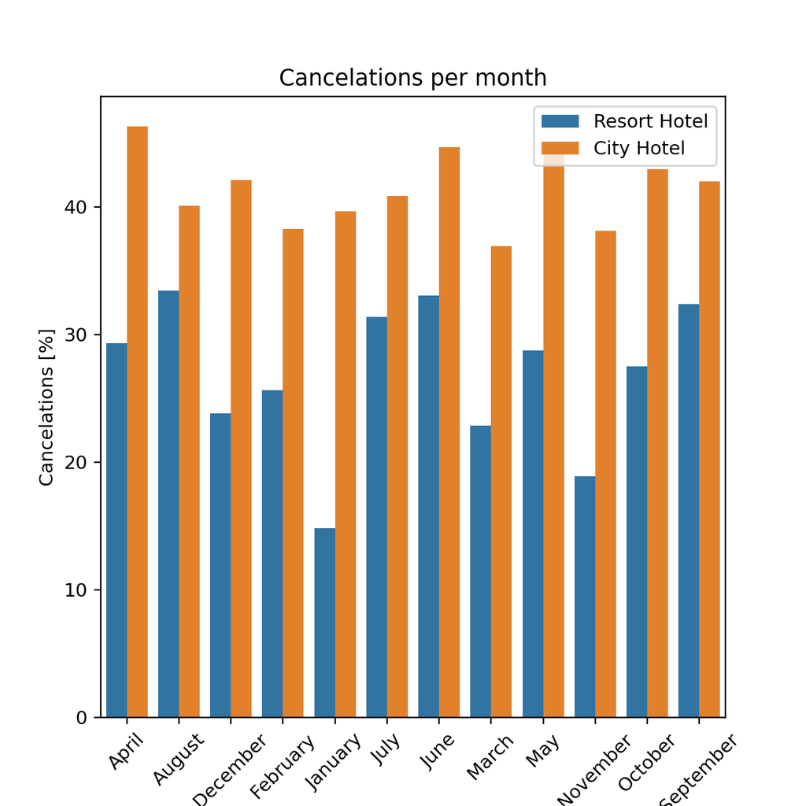

```python
# plotting is simple once we have good dataset.
plt.figure(figsize=(6, 6))
sns.barplot(x = "month", y = "percent_cancel" , hue="hotel",
            hue_order = ["Resort Hotel", "City Hotel"], data=data_visual)
plt.title("Cancelations per month")
plt.xticks(rotation=45)
plt.ylabel("Cancelations [%]")
plt.legend()
plt.show()
```

Previous plot is nice, but the ordering of the month is very annoying!

**Question 1.** Propose a solution that will re-order the barplot above using standard month ordering. Hint: use `pd.Categorical()` function of pandas.

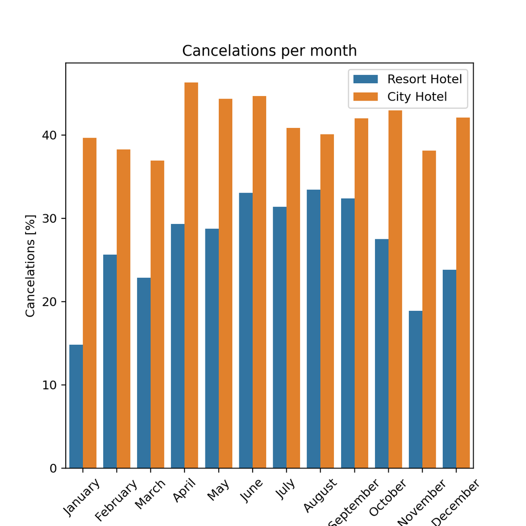

```python
# barplot using standard month ordering
data_visual["month"] = pd.Categorical(data_visual["month"],
categories = ["January", "February", "March", "April", "May", "June", "July", "August",
"September","October", "November", "December"] ,ordered = True)
plt.figure(figsize=(6, 6))
sns.barplot(x = "month", y = "percent_cancel" , hue="hotel",
            hue_order = ["Resort Hotel", "City Hotel"], data=data_visual)
plt.title("Cancelations per month")
plt.xticks(rotation=45)
plt.ylabel("Cancelations [%]")
plt.legend()
plt.show()
```

**Question 2.** Provide interpretation of the above plot.

**Question 3.** What is the most and the second most common country of origin for reservations of each hotel?

```python
# For the first hotel
n_reserv_country_H1 = data.loc[(data["hotel"] == "Resort Hotel")].groupby("country")["hotel"].count()

data_country_H1 = pd.DataFrame({"hotel": "Resort Hotel",
                                "country": list(n_reserv_country_H1.index),
                                "n_booking": list(n_reserv_country_H1.values)})

# For the second hotel
n_reserv_country_H2 = data.loc[(data["hotel"] == "City Hotel")].groupby("country")["hotel"].count()


data_country_H2 = pd.DataFrame({"hotel": "City Hotel",
                                "country": list(n_reserv_country_H2.index),
                                "n_booking": list(n_reserv_country_H2.values)})
```

```python
data_country_H1.sort_values("n_booking", ascending=False).head(2)
```

|  | hotel | country | n_booking |
| --- | --- | --- | --- |
| 95 | Resort Hotel | PRT | 17630 |
| 45 | Resort Hotel | GBR | 6814 |

```python
data_country_H2.sort_values("n_booking", ascending=False).head(2)
```

|  | hotel | country | n_booking |
| --- | --- | --- | --- |
| 125 | City Hotel | PRT | 30960 |
| 50 | City Hotel | FRA | 8804 |

**Question 4.** Plot the number of cancelations for repeated and not repeated guests for both hotels.

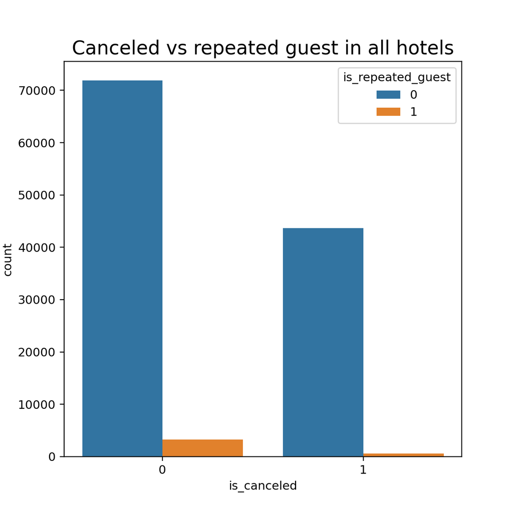

```
[]
```

```python
# Canceled vs repeated guest in all hotels
plt.figure(figsize=(6, 6))
sns.countplot(x="is_canceled", hue='is_repeated_guest', data=data)
plt.title("Canceled vs repeated guest in all hotels", fontsize=16)
plt.plot()
```

**Ploting the number of cancelations for repeated and not repeated guests for Resort Hotel**

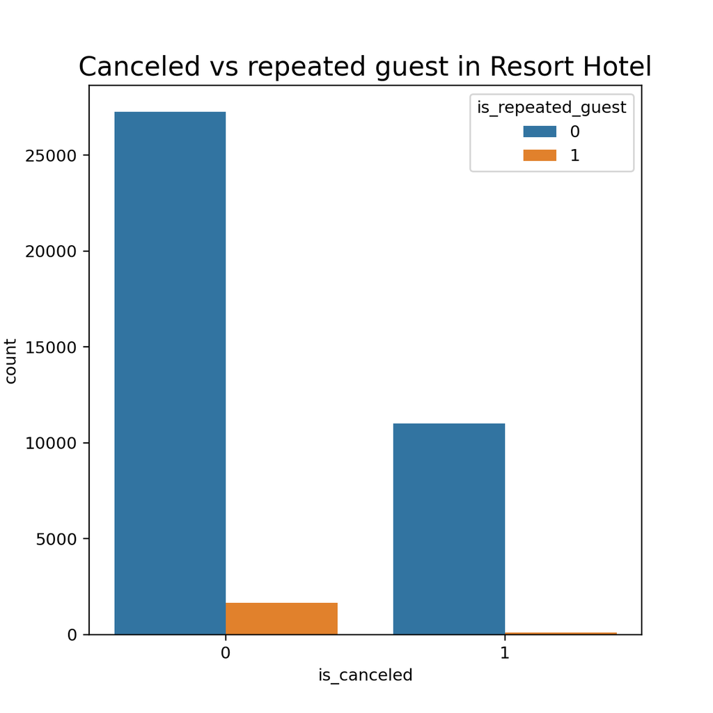

```
[]
```

```python
plt.figure(figsize=(6, 6))
sns.countplot(x="is_canceled", hue='is_repeated_guest', data=data[data["hotel"] == "Resort Hotel"])
plt.title("Canceled vs repeated guest in Resort Hotel", fontsize=16)
plt.plot()
```

**Ploting the number of cancelations for repeated and not repeated guests for City Hotel**

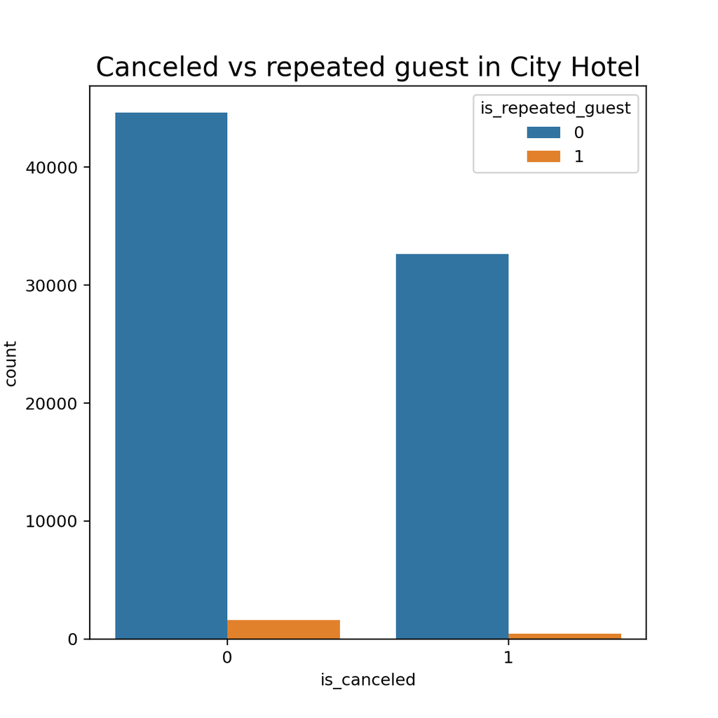

```
[]
```

```python
plt.figure(figsize=(6, 6))
sns.countplot(x="is_canceled", hue='is_repeated_guest', data=data[data["hotel"] == "City Hotel"])
plt.title("Canceled vs repeated guest in City Hotel", fontsize=16)
plt.plot()
```

Most guests in these two hotels are not repeated, while the repreated guests are less likely to cancel.

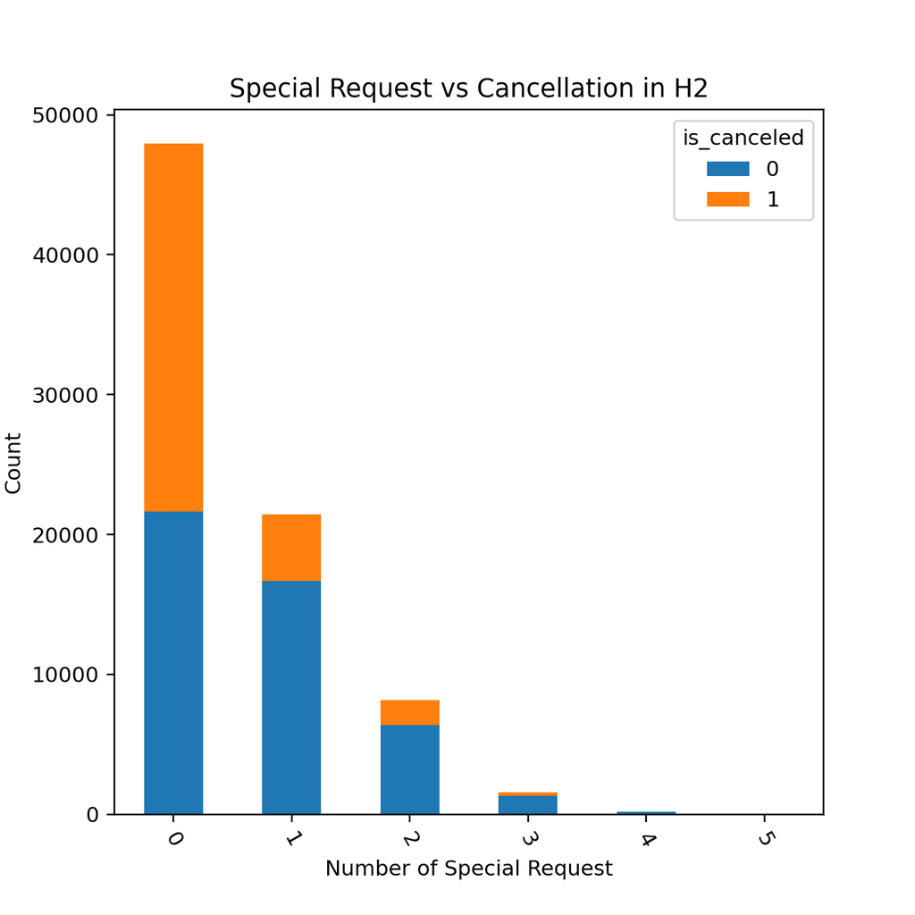

```python
data_req = data[(data['hotel'] == 'City Hotel')].groupby(['total_of_special_requests', 'is_canceled']).size().unstack(level=1)
data_req.plot(kind='bar', stacked=True, figsize=(6,6))
plt.title('Special Request vs Cancellation in H2')
plt.xlabel('Number of Special Request', fontsize=10)
plt.xticks(rotation=300)
plt.ylabel('Count', fontsize=10)
```

Most of the reservations in the city hotel have no special requests and the cancelation in this case is almost 50/50. However, when special requests are made, the cancelation rate is significantly lower.

**Question 5.** Make the same plot for Resort Hotel. Make your conclusions.

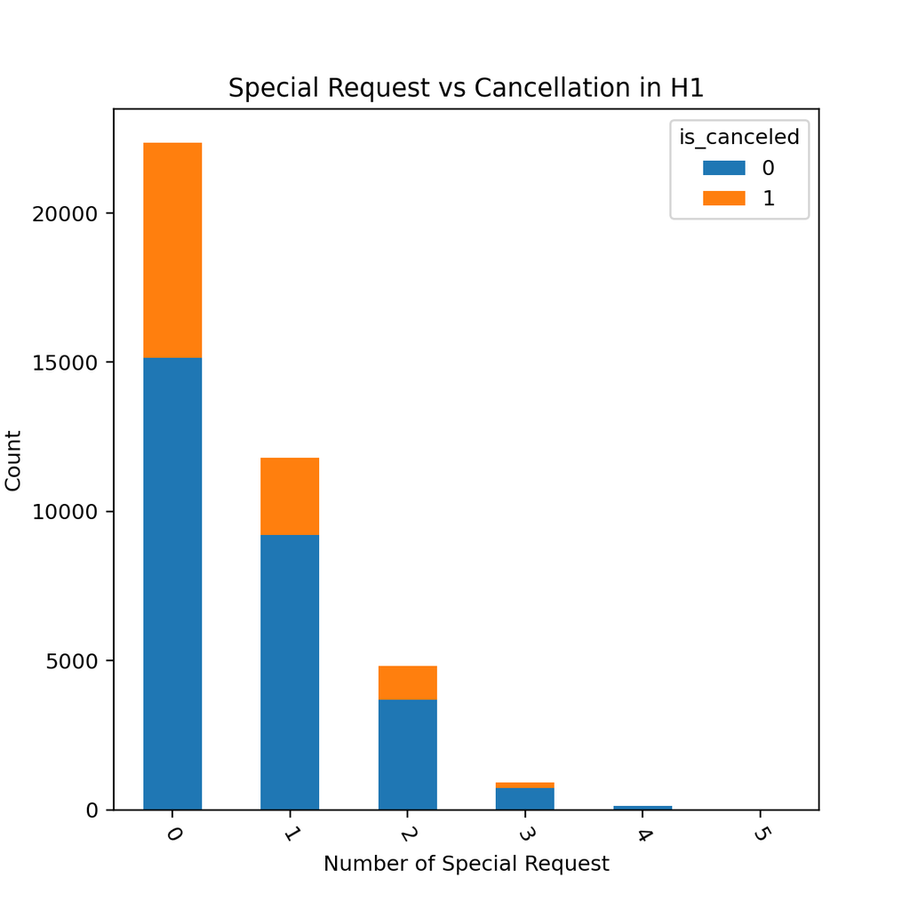

```python
data_req = data[(data['hotel'] == 'Resort Hotel')].groupby(['total_of_special_requests', 'is_canceled']).size().unstack(level=1)
data_req.plot(kind='bar', stacked=True, figsize=(6,6))
plt.title('Special Request vs Cancellation in H1')
plt.xlabel('Number of Special Request', fontsize=10)
plt.xticks(rotation=300)
plt.ylabel('Count', fontsize=10)
```

# Predicting cancellations: Part II -- ML

**Our goals** The main message here is -- do not re-invent the wheel. The following few lines of code highlight the simplicity with which we can combine `pandas` dataframes and `sklearn` models. By learning few simple tools (i.e. `pipeline`, `gridsearchcv`) our code becomes readable, compact, and can be used to build extra features on top of it.

```python
from sklearn.pipeline import Pipeline
from sklearn.compose import ColumnTransformer
from sklearn.preprocessing import OneHotEncoder, StandardScaler, MaxAbsScaler
from sklearn.impute import SimpleImputer
from sklearn.linear_model import LogisticRegression
from sklearn.model_selection import GridSearchCV
```

```python
numeric_features = ["lead_time", "arrival_date_week_number", "total_of_special_requests"]
categorical_features = ["hotel", "market_segment","deposit_type","customer_type"]
features = numeric_features + categorical_features
X = data.drop(["is_canceled"], axis=1)[features]
y = data["is_canceled"]
```

Before using any ML algorithm from sklearn we need to handle missing values. There is no unique answer on how to deal with missing values in your dataset. We will use possibly the simplest approach. First of all if the feature is numerical and is misisng, we are going to replace it with zero. Secondly, if the feature is categorical and is missing, then we are going to define a new category and call it `Not defined`.

```python
numeric_transformer = SimpleImputer(strategy="constant", fill_value=0) # to deal with missing numeric data
categorical_transformer = Pipeline(steps=[
                                    ("imputer", SimpleImputer(strategy="constant", fill_value="Not defined")),
                                    ("onehot", OneHotEncoder(handle_unknown='ignore'))]) # to deal with missing categorical data
preproc = ColumnTransformer(transformers=[("num", numeric_transformer, numeric_features),
                                          ("cat", categorical_transformer, categorical_features)])
```

**Question 6.** What is `OneHotEncoder()`? Why do we use it in our case?

Now imagine a situation when you want to try a lot of different models and for each model you want to make some cross-validation to select the best hyperparameters. On top of that you want to preprocess the data so that you feed something meaningfull into each method.

The next chunk of code shows how to do it.

```python
models = [("logreg", LogisticRegression(max_iter=500))]
grids = {"logreg" : {'logreg__C': np.logspace(-2, 2, 5, base=2)}}
for name, model in models:
    pipe = Pipeline(steps=[('preprocessor', preproc), (name, model)])
    clf = GridSearchCV(pipe, grids[name], cv=3)
    clf.fit(X, y)
    print('Results for {}'.format(name))
    print(clf.cv_results_)
```

[output not shown]

[output cut: 33 more lines]

[output not shown]

```
Results for logreg
{'mean_fit_time': array([3.64603718, 3.92793409, 3.81150039, 4.70467035, 3.72182274]), 'std_fit_time': array([0.21916078, 0.60371507, 0.20280507, 0.6397076 , 0.08429728]), 'mean_score_time': array([0.06491248, 0.08641632, 0.07610671, 0.0794603 , 0.07857466]), 'std_score_time': array([0.00377297, 0.0…
             mask=[False, False, False, False, False],
       fill_value='?',
            dtype=object), 'params': [{'logreg__C': 0.25}, {'logreg__C': 0.5}, {'logreg__C': 1.0}, {'logreg__C': 2.0}, {'logreg__C': 4.0}], 'split0_test_score': array([0.70128402, 0.70128402, 0.70128402, 0.70153529, 0.6996256 ]), 'split1_test_score': array([0.78181772, 0.78219464, 0.78174234, 0.7821…
```

**Question 7.** In the previous example we again encounter the convergence problem. Of course we can set higher number of iterations, but it is time consuming. As you have seen, proper normalization can resolve the issue. Insert a normalization step in the pipeline. Note that we do not want to normalize the categorical data, it simply does not make sense. Be careful to normalize only the numerical data. Did it resolve the warning?

**Remark:** Note that in this part we picked only a small subset of features. We could have used other features as well.

**Inserting a Normalization Step in the pipeline**

```python
# Normalization Step
numeric_transformer2 = Pipeline(steps=[
                                    ("imputer", SimpleImputer(strategy="constant", fill_value=0)), ('scaler', StandardScaler())])
categorical_transformer2 = Pipeline(steps=[
                                    ("imputer", SimpleImputer(strategy="constant", fill_value="Not defined")),
                                    ("onehot", OneHotEncoder(handle_unknown='ignore'))])
preproc2 = ColumnTransformer(transformers=[("num", numeric_transformer2, numeric_features),
                                          ("cat", categorical_transformer2, categorical_features)])
```

```python
# Logistic regression with normalization
models = [("logreg", LogisticRegression(max_iter=500))]
grids = {"logreg" : {'logreg__C': np.logspace(-2, 2, 5, base=2)}}
for name, model in models:
    pipe = Pipeline(steps=[('preprocessor', preproc2), (name, model)])
    clf1 = GridSearchCV(pipe, grids[name], cv=3)
    clf1.fit(X, y)
    clf1.predict(X)
    print('Results for {}'.format(name))
    print(clf1.cv_results_)
    print('Returned hyperparameter: {}'.format(clf1.best_params_))
    print('Best classification accuracy is: {}'.format(clf1.best_score_))
    print('Classification accuracy on data is: {}'.format(clf1.score(X, y)))
```

```
Results for logreg
{'mean_fit_time': array([1.20625067, 1.17417328, 1.29675937, 1.38129473, 1.13161302]), 'std_fit_time': array([0.14298072, 0.25843275, 0.50568377, 0.39961114, 0.20836399]), 'mean_score_time': array([0.09869631, 0.07886529, 0.0682563 , 0.07034731, 0.08688633]), 'std_score_time': array([0.03221475, 0.0…
             mask=[False, False, False, False, False],
       fill_value='?',
            dtype=object), 'params': [{'logreg__C': 0.25}, {'logreg__C': 0.5}, {'logreg__C': 1.0}, {'logreg__C': 2.0}, {'logreg__C': 4.0}], 'split0_test_score': array([0.70128402, 0.70005277, 0.68628289, 0.67427193, 0.66600498]), 'split1_test_score': array([0.78259668, 0.78244591, 0.78221977, 0.7822…
Returned hyperparameter: {'logreg__C': 0.25}
Best classification accuracy is: 0.7398944292500542
Classification accuracy on data is: 0.7810788173213837
```

**Question 8.** As we can see, previous code uses only logistic regression. Modify the above code inserting your favorite ML method.

**Our favourite Method without train/test data split**

```python
#Random Forest algorithm with normalization
from sklearn.ensemble import RandomForestClassifier
models = [("randomforest", RandomForestClassifier(random_state=42))]
grids = {"randomforest" : {'randomforest__n_estimators': list(range(100, 2001, 100))}}
for name, model in models:
    pipe = Pipeline(steps=[('preprocessor', preproc), (name, model)])
    clf2 = GridSearchCV(pipe, grids[name], cv=3)
    clf2.fit(X, y)
    print('Results for {}'.format(name))
    print(clf2.cv_results_)
    print('Returned hyperparameter: {}'.format(clf2.best_params_))
    print('Best classification accuracy is: {}'.format(clf2.best_score_))
    print('Classification accuracy on train is: {}'.format(clf2.score(X, y)))
```

```
Results for randomforest
{'mean_fit_time': array([ 4.10322857,  8.25045371, 12.29679942, 16.65811268, 20.26070944,
       23.52328936, 27.51790698, 31.92319115, 35.52272662, 39.43358827,
       43.68921089, 48.48275463, 53.25893633, 57.55404639, 61.1933794 ,
       64.86860458, 68.65742596, 72.93901102, 77.65048401, 81.17604733]), 'std_fit_time': array([ 0.56278913,  1.17170459,  1.89664988,  2.40789206,  3.09779176,
        3.54750091,  3.8161442 ,  4.86520541,  5.5279421 ,  5.77393598,
        6.4235596 ,  6.9226899 ,  7.87908059,  8.54515899,  8.95887692,
        9.26832039, 10.05048906, 10.87116025, 11.47869731, 11.72629491]), 'mean_score_time': array([0.29380401, 0.51746225, 0.76248225, 1.01611535, 1.25620596,
       1.43419496, 1.69535844, 1.93022426, 2.14407635, 2.39102705,
       2.68584243, 2.8479267 , 3.20985937, 3.44732229, 3.67410231,
       3.88022939, 4.12625233, 4.38630883, 4.67456444, 4.8703351 ]), 'std_score_time': array([0.10166803, 0.18576133, 0.27959345, 0.38297983, 0.40190718,
       0.5232225 , 0.64757285, 0.70352848, 0.78323268, 0.91311661,
       1.02666868, 1.08350462, 1.20590216, 1.28880055, 1.36245237,
       1.4377587 , 1.5215639 , 1.63090805, 1.68401263, 1.80148688]), 'param_randomforest__n_estimators': masked_array(data=[100, 200, 300, 400, 500, 600, 700, 800, 900, 1000,
                   1100, 1200, 1300, 1400, 1500, 1600, 1700, 1800, 1900,
                   2000],
             mask=[False, False, False, False, False, False, False, False,
                   False, False, False, False, False, False, False, False,
                   False, False, False, False],
       fill_value='?',
            dtype=object), 'params': [{'randomforest__n_estimators': 100}, {'randomforest__n_estimators': 200}, {'randomforest__n_estimators': 300}, {'randomforest__n_estimators': 400}, {'randomforest__n_estimators': 500}, {'randomforest__n_estimators': 600}, {'randomforest__n_estimators': 700}, {'r…
       0.12712013, 0.12712013, 0.12712013, 0.12712013, 0.12712013,
       0.12712013, 0.12712013, 0.12712013, 0.12709501, 0.12709501,
       0.12709501, 0.12709501, 0.12709501, 0.12709501, 0.12709501]), 'split1_test_score': array([0.92223032, 0.92107445, 0.92114984, 0.92094882, 0.92004422,
       0.91939091, 0.91964218, 0.91971757, 0.91974269, 0.91976782,
       0.91991859, 0.92011961, 0.92004422, 0.92019499, 0.92042114,
       0.92027037, 0.92049652, 0.92054677, 0.92052165, 0.92042114]), 'split2_test_score': array([0.93896371, 0.93888833, 0.93888833, 0.93883807, 0.93891346,
       0.93883807, 0.93878782, 0.93881295, 0.93881295, 0.93878782,
       0.93878782, 0.93878782, 0.93873756, 0.93873756, 0.93873756,
       0.93876269, 0.93873756, 0.93873756, 0.93876269, 0.93876269]), 'mean_test_score': array([0.66274626, 0.66236935, 0.66239448, 0.66228559, 0.66201756,
       0.66178304, 0.66185005, 0.66188355, 0.66189192, 0.66189192,
       0.66194218, 0.66200919, 0.66196731, 0.66200919, 0.66208457,
       0.66204269, 0.6621097 , 0.66212645, 0.66212645, 0.66209294]), 'std_test_score': array([0.37885977, 0.37853045, 0.37854762, 0.37852512, 0.3783258 ,
       0.37814712, 0.37819192, 0.37821519, 0.3782209 , 0.37822047,
       0.37825474, 0.37830045, 0.37827105, 0.37831719, 0.37836864,
       0.37834046, 0.3783858 , 0.37839724, 0.37839764, 0.37837477]), 'rank_test_score': array([ 1,  3,  2,  4, 11, 20, 19, 18, 16, 17, 15, 12, 14, 13,  9, 10,  7,
        6,  5,  8], dtype=int32)}
Returned hyperparameter: {'randomforest__n_estimators': 100}
Best classification accuracy is: 0.6627462619771586
Classification accuracy on train is: 0.967199932992713
```

**Data split into train and test**

```python
# Divide data on train and test
from sklearn.model_selection import train_test_split
X_train, X_test, y_train, y_test =train_test_split(X,y, test_size = .2, random_state=0)
```

**Our favorite ML method with sample division into train and test**

```python
#Random Forest algorithm with normalization and Data split into train and test
from sklearn.ensemble import RandomForestClassifier
models = [("randomforest", RandomForestClassifier(random_state=42))]
grids = {"randomforest" : {'randomforest__n_estimators': list(range(100, 2001, 100))}}
for name, model in models:
    pipe = Pipeline(steps=[('preprocessor', preproc), (name, model)])
    clf4 = GridSearchCV(pipe, grids[name], cv=3)
    clf4.fit(X_train, y_train)
    clf4.predict(X_test)
    print('Results for {}'.format(name))
    print(clf4.cv_results_)
    print('Returned hyperparameter: {}'.format(clf4.best_params_))
    print('Best classification accuracy is: {}'.format(clf4.best_score_))
    print('Classification accuracy on train is: {}'.format(clf4.score(X_train, y_train)))
    print('Classification accuracy on test is: {}'.format(clf4.score(X_test, y_test)))
```

```
Results for randomforest
{'mean_fit_time': array([ 3.70490551,  7.5506626 , 11.07227659, 14.72337071, 18.95310481,
       22.0869027 , 26.32730134, 30.06241727, 33.79545506, 37.97099066,
       41.92149615, 45.75728655, 49.49117486, 52.72128654, 56.62804317,
       59.1512684 , 65.96932824, 68.07272267, 72.82696366, 75.71327909]), 'std_fit_time': array([0.0307967 , 0.22073264, 0.13170406, 0.14871038, 0.68562813,
       0.17277112, 0.16110109, 0.09810242, 0.17431288, 0.09351223,
       0.18474279, 0.37285707, 0.13326409, 0.16415647, 0.28948942,
       0.55167443, 0.74964274, 1.2869847 , 0.79221911, 0.70412756]), 'mean_score_time': array([0.49046016, 0.9835763 , 1.3667678 , 1.85551159, 2.2978429 ,
       2.79179565, 3.37863898, 3.82448753, 4.26446629, 4.79529627,
       5.24017866, 5.70636996, 6.25686312, 6.64972933, 7.1221869 ,
       7.42417034, 8.11320869, 8.4089516 , 9.09298865, 9.58448259]), 'std_score_time': array([0.02012389, 0.00829676, 0.0384896 , 0.02917171, 0.0856294 ,
       0.02766507, 0.0554473 , 0.00926685, 0.03599138, 0.04778032,
       0.05945848, 0.01451596, 0.04934358, 0.05225497, 0.01146153,
       0.09076449, 0.10242022, 0.36958775, 0.0593847 , 0.00936841]), 'param_randomforest__n_estimators': masked_array(data=[100, 200, 300, 400, 500, 600, 700, 800, 900, 1000,
                   1100, 1200, 1300, 1400, 1500, 1600, 1700, 1800, 1900,
                   2000],
             mask=[False, False, False, False, False, False, False, False,
                   False, False, False, False, False, False, False, False,
                   False, False, False, False],
       fill_value='?',
            dtype=object), 'params': [{'randomforest__n_estimators': 100}, {'randomforest__n_estimators': 200}, {'randomforest__n_estimators': 300}, {'randomforest__n_estimators': 400}, {'randomforest__n_estimators': 500}, {'randomforest__n_estimators': 600}, {'randomforest__n_estimators': 700}, {'r…
       0.9225768 , 0.92229411, 0.92248257, 0.92263961, 0.9225768 ,
       0.92235693, 0.9226082 , 0.92241975, 0.92232552, 0.92229411,
       0.92232552, 0.92229411, 0.9222627 , 0.92216848, 0.9222313 ]), 'split1_test_score': array([0.9214436 , 0.92229167, 0.92235449, 0.92219744, 0.92216603,
       0.92235449, 0.92254295, 0.92254295, 0.92254295, 0.92232308,
       0.92251154, 0.92226026, 0.9223859 , 0.9223859 , 0.92251154,
       0.92248013, 0.92248013, 0.92235449, 0.92244872, 0.92244872]), 'split2_test_score': array([0.92003015, 0.92043848, 0.9205013 , 0.92043848, 0.92053271,
       0.92040707, 0.92056412, 0.9205013 , 0.92043848, 0.9205013 ,
       0.92056412, 0.92062694, 0.92062694, 0.92078399, 0.92084681,
       0.92075258, 0.92075258, 0.92078399, 0.92072117, 0.92059553]), 'mean_test_score': array([0.92113032, 0.9216957 , 0.92172711, 0.92171663, 0.92171664,
       0.92177945, 0.9218004 , 0.92184227, 0.92187368, 0.92180039,
       0.92181087, 0.9218318 , 0.92181087, 0.92183181, 0.92188416,
       0.92185275, 0.92184228, 0.9218004 , 0.92177946, 0.92175852]), 'std_test_score': array([0.0008016 , 0.00088938, 0.00086685, 0.00091298, 0.00084521,
       0.00097465, 0.00088006, 0.00094853, 0.00101561, 0.00092442,
       0.00088384, 0.00086373, 0.00083727, 0.00074133, 0.00073886,
       0.00078049, 0.00077426, 0.00071968, 0.00075702, 0.00082713]), 'rank_test_score': array([20, 19, 16, 18, 17, 14, 11,  5,  2, 12,  8,  7,  9,  6,  1,  3,  4,
       10, 13, 15], dtype=int32)}
Returned hyperparameter: {'randomforest__n_estimators': 1500}
Best classification accuracy is: 0.9218841568603202
Classification accuracy on train is: 0.9700247089370969
Classification accuracy on test is: 0.9218527514867242
```

**Logistic regression with normalization and sample division into train and test**

```python
# Logistic regression with normalization and sample division on train and test
models = [("logreg", LogisticRegression(max_iter=500))]
grids = {"logreg" : {'logreg__C': np.logspace(-2, 2, 5, base=2)}}
for name, model in models:
    pipe = Pipeline(steps=[('preprocessor', preproc2), (name, model)])
    clf3 = GridSearchCV(pipe, grids[name], cv=3)
    clf3.fit(X_train, y_train)
    clf3.predict(X_test)
    print('Results for {}'.format(name))
    print(clf3.cv_results_)
    print('Returned hyperparameter: {}'.format(clf3.best_params_))
    print('Best classification accuracy is: {}'.format(clf3.best_score_))
    print('Classification accuracy on train is: {}'.format(clf3.score(X_train, y_train)))
    print('Classification accuracy on test is: {}'.format(clf3.score(X_test, y_test)))
```

```
Results for logreg
{'mean_fit_time': array([0.47968698, 0.55097198, 0.63348635, 0.73527439, 0.8574264 ]), 'std_fit_time': array([0.0241817 , 0.03673042, 0.03281468, 0.04011698, 0.07953678]), 'mean_score_time': array([0.04488635, 0.04622674, 0.04399967, 0.04829566, 0.04527203]), 'std_score_time': array([0.00213624, 0.0…
             mask=[False, False, False, False, False],
       fill_value='?',
            dtype=object), 'params': [{'logreg__C': 0.25}, {'logreg__C': 0.5}, {'logreg__C': 1.0}, {'logreg__C': 2.0}, {'logreg__C': 4.0}], 'split0_test_score': array([0.93774735, 0.93774735, 0.93774735, 0.93774735, 0.93774735]), 'split1_test_score': array([0.93780821, 0.93780821, 0.93780821, 0.9378…
       2.86918635e-05]), 'rank_test_score': array([1, 1, 1, 1, 1], dtype=int32)}
Returned hyperparameter: {'logreg__C': 0.25}
Best classification accuracy is: 0.9377879223613412
Classification accuracy on train is: 0.9377983918251109
Classification accuracy on test is: 0.9381438981489237
```

# The homework

**The story!** You are a data scientist working for the hotel, one day the manager comes and tells you.

In our hotels we have an option to offer a parking spot, which costs money. Apparently, not every customer is aware that we have such an option. I really want to offer parking spots for everyone who needs it, because the hotel can earn more money like that. Look, I can send an SMS notification to our customers. Of course SMS are not free, and, moreover, people get very much angry if they receive stupid notifications for no reason. For each new reservation, I would like to decide if I should or shouldn't send the notification to the customer.

**Problem** Explore your data to help the manager and construct a prediction algorithm, using the above template as an inspiration.

**Warning!** Be aware, that some columns are not actually avaiable at the moment of reservation. For instance, the target column `is_canceled` from the previous part clearly cannot be observed at the moment when we need to decide to send the SMS.

```python
data.columns # print column names
```

```
Index(['hotel', 'is_canceled', 'lead_time', 'arrival_date_year',
       'arrival_date_month', 'arrival_date_week_number',
       'arrival_date_day_of_month', 'stays_in_weekend_nights',
       'stays_in_week_nights', 'adults', 'children', 'babies', 'meal',
       'country', 'market_segment', 'distribution_channel',
       'is_repeated_guest', 'previous_cancellations',
       'previous_bookings_not_canceled', 'reserved_room_type',
       'assigned_room_type', 'booking_changes', 'deposit_type', 'agent',
       'company', 'days_in_waiting_list', 'customer_type', 'adr',
       'required_car_parking_spaces', 'total_of_special_requests',
       'reservation_status', 'reservation_status_date'],
      dtype='object')
```

**Amount of missing values**

```python
data.isnull().sum()
```

```
hotel                                  0
is_canceled                            0
lead_time                              0
arrival_date_year                      0
arrival_date_month                     0
arrival_date_week_number               0
arrival_date_day_of_month              0
stays_in_weekend_nights                0
stays_in_week_nights                   0
adults                                 0
children                               4
babies                                 0
meal                                   0
country                              488
market_segment                         0
distribution_channel                   0
is_repeated_guest                      0
previous_cancellations                 0
previous_bookings_not_canceled         0
reserved_room_type                     0
assigned_room_type                     0
booking_changes                        0
deposit_type                           0
agent                              16340
company                           112593
days_in_waiting_list                   0
customer_type                          0
adr                                    0
required_car_parking_spaces            0
total_of_special_requests              0
reservation_status                     0
reservation_status_date                0
dtype: int64
```

**Defining the label**

```python
data["required_car_parking_spaces"].unique()
```

```
array([0, 1, 2, 8, 3])
```

```python
# Creation of the label
data["need_car_parking_spot"] = data["required_car_parking_spaces"].apply(lambda x:x>0).astype('uint8')
```

```python
data["need_car_parking_spot"].unique()
```

```
array([0, 1], dtype=uint8)
```

**Data exploration**

```python
data.columns # print column names
```

```
Index(['hotel', 'is_canceled', 'lead_time', 'arrival_date_year',
       'arrival_date_month', 'arrival_date_week_number',
       'arrival_date_day_of_month', 'stays_in_weekend_nights',
       'stays_in_week_nights', 'adults', 'children', 'babies', 'meal',
       'country', 'market_segment', 'distribution_channel',
       'is_repeated_guest', 'previous_cancellations',
       'previous_bookings_not_canceled', 'reserved_room_type',
       'assigned_room_type', 'booking_changes', 'deposit_type', 'agent',
       'company', 'days_in_waiting_list', 'customer_type', 'adr',
       'required_car_parking_spaces', 'total_of_special_requests',
       'reservation_status', 'reservation_status_date',
       'need_car_parking_spot'],
      dtype='object')
```

**Numeric features exploration**

```python
# All the observable numeric features
all_numeric_features = ["arrival_date_week_number", "adults","children", "babies" ,"booking_changes" ,"total_of_special_requests", "stays_in_weekend_nights", "stays_in_week_nights", "previous_bookings_not_canceled", "arrival_date_year", "arrival_date_day_of_month", "lead_time", "days_in_waiting_list", "previous_cancellations"]
```

```python
data[all_numeric_features]
```

|  | arrival_date_week_number | adults | children | babies | booking_changes | total_of_special_requests | stays_in_weekend_nights | stays_in_week_nights | previous_bookings_not_canceled | arrival_date_year | arrival_date_day_of_month | lead_time | days_in_waiting_list | previous_cancellations |
| --- | --- | --- | --- | --- | --- | --- | --- | --- | --- | --- | --- | --- | --- | --- |
| 0 | 27 | 2 | 0.0 | 0 | 3 | 0 | 0 | 0 | 0 | 2015 | 1 | 342 | 0 | 0 |
| 1 | 27 | 2 | 0.0 | 0 | 4 | 0 | 0 | 0 | 0 | 2015 | 1 | 737 | 0 | 0 |
| 2 | 27 | 1 | 0.0 | 0 | 0 | 0 | 0 | 1 | 0 | 2015 | 1 | 7 | 0 | 0 |
| 3 | 27 | 1 | 0.0 | 0 | 0 | 0 | 0 | 1 | 0 | 2015 | 1 | 13 | 0 | 0 |
| 4 | 27 | 2 | 0.0 | 0 | 0 | 1 | 0 | 2 | 0 | 2015 | 1 | 14 | 0 | 0 |
| ... | ... | ... | ... | ... | ... | ... | ... | ... | ... | ... | ... | ... | ... | ... |
| 119385 | 35 | 2 | 0.0 | 0 | 0 | 0 | 2 | 5 | 0 | 2017 | 30 | 23 | 0 | 0 |
| 119386 | 35 | 3 | 0.0 | 0 | 0 | 2 | 2 | 5 | 0 | 2017 | 31 | 102 | 0 | 0 |
| 119387 | 35 | 2 | 0.0 | 0 | 0 | 4 | 2 | 5 | 0 | 2017 | 31 | 34 | 0 | 0 |
| 119388 | 35 | 2 | 0.0 | 0 | 0 | 0 | 2 | 5 | 0 | 2017 | 31 | 109 | 0 | 0 |
| 119389 | 35 | 2 | 0.0 | 0 | 0 | 2 | 2 | 7 | 0 | 2017 | 29 | 205 | 0 | 0 |

119390 rows × 14 columns

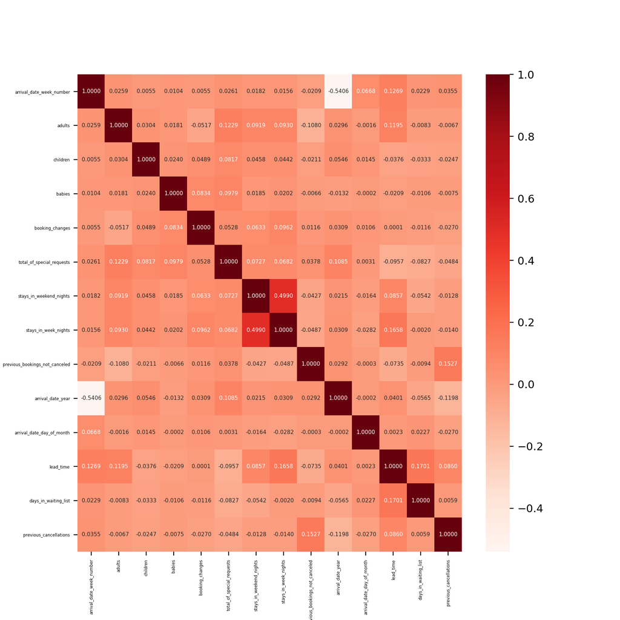

```python
import seaborn as sns

plt.figure(figsize=(8,8))

corr_matrix = data[all_numeric_features].corr(method = 'pearson')
cm=sns.heatmap(corr_matrix, annot=True, cmap=plt.cm.Reds, fmt=".4f",annot_kws={'size':5}) #matrice des corrélations
cm.tick_params(labelsize=3.8)
plt.show()
```

```python
plt.savefig('books_read.png')
```

```python
# Définition du rapport de correlation
def correlation_ratio(categories, measurements):
        fcat, _ = pd.factorize(categories)
        cat_num = np.max(fcat)+1
        y_avg_array = np.zeros(cat_num)
        n_array = np.zeros(cat_num)
        for i in range(0,cat_num):
            cat_measures = measurements[np.argwhere(fcat == i).flatten()]
            n_array[i] = len(cat_measures)
            y_avg_array[i] = np.average(cat_measures)
        y_total_avg = np.sum(np.multiply(y_avg_array,n_array))/np.sum(n_array)
        numerator = np.sum(np.multiply(n_array,np.power(np.subtract(y_avg_array,y_total_avg),2)))
        denominator = np.sum(np.power(np.subtract(measurements,y_total_avg),2))
        if numerator == 0:
            eta = 0.0
        else:
            eta = numerator/denominator
        return eta
```

```python
data[data["children"].isna() == False]
```

|  | hotel | is_canceled | lead_time | arrival_date_year | arrival_date_month | arrival_date_week_number | arrival_date_day_of_month | stays_in_weekend_nights | stays_in_week_nights | adults | ... | agent | company | days_in_waiting_list | customer_type | adr | required_car_parking_spaces | total_of_special_requests | reservation_status | reservation_status_date | need_car_parking_spot |
| --- | --- | --- | --- | --- | --- | --- | --- | --- | --- | --- | --- | --- | --- | --- | --- | --- | --- | --- | --- | --- | --- |
| 0 | Resort Hotel | 0 | 342 | 2015 | July | 27 | 1 | 0 | 0 | 2 | ... | NaN | NaN | 0 | Transient | 0.00 | 0 | 0 | Check-Out | 2015-07-01 | 0 |
| 1 | Resort Hotel | 0 | 737 | 2015 | July | 27 | 1 | 0 | 0 | 2 | ... | NaN | NaN | 0 | Transient | 0.00 | 0 | 0 | Check-Out | 2015-07-01 | 0 |
| 2 | Resort Hotel | 0 | 7 | 2015 | July | 27 | 1 | 0 | 1 | 1 | ... | NaN | NaN | 0 | Transient | 75.00 | 0 | 0 | Check-Out | 2015-07-02 | 0 |
| 3 | Resort Hotel | 0 | 13 | 2015 | July | 27 | 1 | 0 | 1 | 1 | ... | 304.0 | NaN | 0 | Transient | 75.00 | 0 | 0 | Check-Out | 2015-07-02 | 0 |
| 4 | Resort Hotel | 0 | 14 | 2015 | July | 27 | 1 | 0 | 2 | 2 | ... | 240.0 | NaN | 0 | Transient | 98.00 | 0 | 1 | Check-Out | 2015-07-03 | 0 |
| ... | ... | ... | ... | ... | ... | ... | ... | ... | ... | ... | ... | ... | ... | ... | ... | ... | ... | ... | ... | ... | ... |
| 119385 | City Hotel | 0 | 23 | 2017 | August | 35 | 30 | 2 | 5 | 2 | ... | 394.0 | NaN | 0 | Transient | 96.14 | 0 | 0 | Check-Out | 2017-09-06 | 0 |
| 119386 | City Hotel | 0 | 102 | 2017 | August | 35 | 31 | 2 | 5 | 3 | ... | 9.0 | NaN | 0 | Transient | 225.43 | 0 | 2 | Check-Out | 2017-09-07 | 0 |
| 119387 | City Hotel | 0 | 34 | 2017 | August | 35 | 31 | 2 | 5 | 2 | ... | 9.0 | NaN | 0 | Transient | 157.71 | 0 | 4 | Check-Out | 2017-09-07 | 0 |
| 119388 | City Hotel | 0 | 109 | 2017 | August | 35 | 31 | 2 | 5 | 2 | ... | 89.0 | NaN | 0 | Transient | 104.40 | 0 | 0 | Check-Out | 2017-09-07 | 0 |
| 119389 | City Hotel | 0 | 205 | 2017 | August | 35 | 29 | 2 | 7 | 2 | ... | 9.0 | NaN | 0 | Transient | 151.20 | 0 | 2 | Check-Out | 2017-09-07 | 0 |

119386 rows × 33 columns

```python
data2 = data.copy()
data2 = data2[data2["children"].isna()== False]
data2 = data2.reset_index(drop=True)
data2
```

|  | hotel | is_canceled | lead_time | arrival_date_year | arrival_date_month | arrival_date_week_number | arrival_date_day_of_month | stays_in_weekend_nights | stays_in_week_nights | adults | ... | agent | company | days_in_waiting_list | customer_type | adr | required_car_parking_spaces | total_of_special_requests | reservation_status | reservation_status_date | need_car_parking_spot |
| --- | --- | --- | --- | --- | --- | --- | --- | --- | --- | --- | --- | --- | --- | --- | --- | --- | --- | --- | --- | --- | --- |
| 0 | Resort Hotel | 0 | 342 | 2015 | July | 27 | 1 | 0 | 0 | 2 | ... | NaN | NaN | 0 | Transient | 0.00 | 0 | 0 | Check-Out | 2015-07-01 | 0 |
| 1 | Resort Hotel | 0 | 737 | 2015 | July | 27 | 1 | 0 | 0 | 2 | ... | NaN | NaN | 0 | Transient | 0.00 | 0 | 0 | Check-Out | 2015-07-01 | 0 |
| 2 | Resort Hotel | 0 | 7 | 2015 | July | 27 | 1 | 0 | 1 | 1 | ... | NaN | NaN | 0 | Transient | 75.00 | 0 | 0 | Check-Out | 2015-07-02 | 0 |
| 3 | Resort Hotel | 0 | 13 | 2015 | July | 27 | 1 | 0 | 1 | 1 | ... | 304.0 | NaN | 0 | Transient | 75.00 | 0 | 0 | Check-Out | 2015-07-02 | 0 |
| 4 | Resort Hotel | 0 | 14 | 2015 | July | 27 | 1 | 0 | 2 | 2 | ... | 240.0 | NaN | 0 | Transient | 98.00 | 0 | 1 | Check-Out | 2015-07-03 | 0 |
| ... | ... | ... | ... | ... | ... | ... | ... | ... | ... | ... | ... | ... | ... | ... | ... | ... | ... | ... | ... | ... | ... |
| 119381 | City Hotel | 0 | 23 | 2017 | August | 35 | 30 | 2 | 5 | 2 | ... | 394.0 | NaN | 0 | Transient | 96.14 | 0 | 0 | Check-Out | 2017-09-06 | 0 |
| 119382 | City Hotel | 0 | 102 | 2017 | August | 35 | 31 | 2 | 5 | 3 | ... | 9.0 | NaN | 0 | Transient | 225.43 | 0 | 2 | Check-Out | 2017-09-07 | 0 |
| 119383 | City Hotel | 0 | 34 | 2017 | August | 35 | 31 | 2 | 5 | 2 | ... | 9.0 | NaN | 0 | Transient | 157.71 | 0 | 4 | Check-Out | 2017-09-07 | 0 |
| 119384 | City Hotel | 0 | 109 | 2017 | August | 35 | 31 | 2 | 5 | 2 | ... | 89.0 | NaN | 0 | Transient | 104.40 | 0 | 0 | Check-Out | 2017-09-07 | 0 |
| 119385 | City Hotel | 0 | 205 | 2017 | August | 35 | 29 | 2 | 7 | 2 | ... | 9.0 | NaN | 0 | Transient | 151.20 | 0 | 2 | Check-Out | 2017-09-07 | 0 |

119386 rows × 33 columns

```python
data2["children"].unique()
```

```
array([ 0.,  1.,  2., 10.,  3.])
```

```python
corr_label = []
for i in range(0,14):
    corr_label.append(correlation_ratio(data2.need_car_parking_spot, data2[all_numeric_features].iloc[:,i]))
```

```python
corr_tab=pd.DataFrame(corr_label, index= all_numeric_features)
corr_tab
```

|  | 0 |
| --- | --- |
| arrival_date_week_number | 0.000008 |
| adults | 0.000214 |
| children | 0.003238 |
| babies | 0.001427 |
| booking_changes | 0.004275 |
| total_of_special_requests | 0.006975 |
| stays_in_weekend_nights | 0.000387 |
| stays_in_week_nights | 0.000685 |
| previous_bookings_not_canceled | 0.002293 |
| arrival_date_year | 0.000221 |
| arrival_date_day_of_month | 0.000073 |
| lead_time | 0.013952 |
| days_in_waiting_list | 0.001060 |
| previous_cancellations | 0.000347 |

**Categorical features exploration**

```python
# all the observable categorical features
all_categorical_features = ["hotel", "market_segment","reserved_room_type", "deposit_type","customer_type", "distribution_channel", "meal", "country", "arrival_date_month", "is_repeated_guest"]
```

```python
data[data["country"].isna() == False]
```

|  | hotel | is_canceled | lead_time | arrival_date_year | arrival_date_month | arrival_date_week_number | arrival_date_day_of_month | stays_in_weekend_nights | stays_in_week_nights | adults | ... | agent | company | days_in_waiting_list | customer_type | adr | required_car_parking_spaces | total_of_special_requests | reservation_status | reservation_status_date | need_car_parking_spot |
| --- | --- | --- | --- | --- | --- | --- | --- | --- | --- | --- | --- | --- | --- | --- | --- | --- | --- | --- | --- | --- | --- |
| 0 | Resort Hotel | 0 | 342 | 2015 | July | 27 | 1 | 0 | 0 | 2 | ... | NaN | NaN | 0 | Transient | 0.00 | 0 | 0 | Check-Out | 2015-07-01 | 0 |
| 1 | Resort Hotel | 0 | 737 | 2015 | July | 27 | 1 | 0 | 0 | 2 | ... | NaN | NaN | 0 | Transient | 0.00 | 0 | 0 | Check-Out | 2015-07-01 | 0 |
| 2 | Resort Hotel | 0 | 7 | 2015 | July | 27 | 1 | 0 | 1 | 1 | ... | NaN | NaN | 0 | Transient | 75.00 | 0 | 0 | Check-Out | 2015-07-02 | 0 |
| 3 | Resort Hotel | 0 | 13 | 2015 | July | 27 | 1 | 0 | 1 | 1 | ... | 304.0 | NaN | 0 | Transient | 75.00 | 0 | 0 | Check-Out | 2015-07-02 | 0 |
| 4 | Resort Hotel | 0 | 14 | 2015 | July | 27 | 1 | 0 | 2 | 2 | ... | 240.0 | NaN | 0 | Transient | 98.00 | 0 | 1 | Check-Out | 2015-07-03 | 0 |
| ... | ... | ... | ... | ... | ... | ... | ... | ... | ... | ... | ... | ... | ... | ... | ... | ... | ... | ... | ... | ... | ... |
| 119385 | City Hotel | 0 | 23 | 2017 | August | 35 | 30 | 2 | 5 | 2 | ... | 394.0 | NaN | 0 | Transient | 96.14 | 0 | 0 | Check-Out | 2017-09-06 | 0 |
| 119386 | City Hotel | 0 | 102 | 2017 | August | 35 | 31 | 2 | 5 | 3 | ... | 9.0 | NaN | 0 | Transient | 225.43 | 0 | 2 | Check-Out | 2017-09-07 | 0 |
| 119387 | City Hotel | 0 | 34 | 2017 | August | 35 | 31 | 2 | 5 | 2 | ... | 9.0 | NaN | 0 | Transient | 157.71 | 0 | 4 | Check-Out | 2017-09-07 | 0 |
| 119388 | City Hotel | 0 | 109 | 2017 | August | 35 | 31 | 2 | 5 | 2 | ... | 89.0 | NaN | 0 | Transient | 104.40 | 0 | 0 | Check-Out | 2017-09-07 | 0 |
| 119389 | City Hotel | 0 | 205 | 2017 | August | 35 | 29 | 2 | 7 | 2 | ... | 9.0 | NaN | 0 | Transient | 151.20 | 0 | 2 | Check-Out | 2017-09-07 | 0 |

118902 rows × 33 columns

```python
data3 = data.copy()
data3 = data3[data3["country"].isna()== False]
data3 = data3.reset_index(drop=True)
```

```python
from scipy import stats
for numeric in all_categorical_features:
    print(stats.spearmanr(data3[[numeric, "need_car_parking_spot"]]))
```

```
SpearmanrResult(correlation=0.2191334235873404, pvalue=0.0)
SpearmanrResult(correlation=-0.0311011156912504, pvalue=7.617144317002537e-27)
SpearmanrResult(correlation=0.12154566894142614, pvalue=0.0)
SpearmanrResult(correlation=-0.09399919661772066, pvalue=1.7615471062237836e-231)
SpearmanrResult(correlation=-0.050708630584633256, pvalue=1.5232677954551167e-68)
SpearmanrResult(correlation=-0.13773117959885858, pvalue=0.0)
SpearmanrResult(correlation=-0.03524701902003104, pvalue=5.2280608196530004e-34)
SpearmanrResult(correlation=-0.005165978038646425, pvalue=0.07485782955879906)
SpearmanrResult(correlation=-0.01984225032263943, pvalue=7.774685511887175e-12)
SpearmanrResult(correlation=0.07598438392243852, pvalue=9.612825746387989e-152)
```

**Prediction with all observable features**

```python
all_numeric_features = ["arrival_date_week_number", "adults","children", "babies" ,"booking_changes" ,"total_of_special_requests", "stays_in_weekend_nights", "stays_in_week_nights", "previous_bookings_not_canceled", "arrival_date_year", "arrival_date_day_of_month", "lead_time", "days_in_waiting_list", "previous_cancellations"]
all_categorical_features = ["hotel", "market_segment","reserved_room_type", "deposit_type","customer_type", "distribution_channel", "meal", "country", "arrival_date_month", "is_repeated_guest"]
features = all_numeric_features + all_categorical_features
X = data.drop(["need_car_parking_spot"], axis=1)[features]
y = data["need_car_parking_spot"]
```

```python
# Divide data on train and test
from sklearn.model_selection import train_test_split
X_train, X_test, y_train, y_test =train_test_split(X,y, test_size = .2, random_state=0)
```

```python
numeric_transformer3 = Pipeline(steps=[
                                    ("imputer", SimpleImputer(strategy="constant", fill_value=0)), ('scaler', StandardScaler())])
categorical_transformer3 = Pipeline(steps=[
                                    ("imputer", SimpleImputer(strategy="constant", fill_value="Not defined")),
                                    ("onehot", OneHotEncoder(handle_unknown='ignore'))])
preproc3 = ColumnTransformer(transformers=[("num", numeric_transformer3, all_numeric_features),
                                          ("cat", categorical_transformer3, all_categorical_features)])
```

```python
# Logistic regression with train test split and normalization
parking_model = [("logreg", LogisticRegression(max_iter=1000))]
parking_grids = {"logreg" : {'logreg__C': np.logspace(-2, 2, 5, base=2)}}
for name, model in parking_model:
    parking_pipe = Pipeline(steps=[('preprocessor', preproc3), (name, model)])
    clf9 = GridSearchCV(parking_pipe, parking_grids[name], cv=3)
    clf9.fit(X_train, y_train)
    print('Results for {}'.format(name))
    print(clf9.cv_results_)
    print('Returned hyperparameter: {}'.format(clf9.best_params_))
    print('Best classification accuracy is: {}'.format(clf9.best_score_))
    print('Classification accuracy on train is: {}'.format(clf9.score(X_train, y_train)))
    print('Classification accuracy on test is: {}'.format(clf9.score(X_test, y_test)))
```

```
Results for logreg
{'mean_fit_time': array([1.97539139, 2.52713927, 3.04290477, 4.01697826, 4.91277607]), 'std_fit_time': array([0.14623692, 0.00614227, 0.07772238, 0.08275052, 0.12142831]), 'mean_score_time': array([0.14734197, 0.13316107, 0.135288  , 0.13331842, 0.13149913]), 'std_score_time': array([0.01501435, 0.0…
             mask=[False, False, False, False, False],
       fill_value='?',
            dtype=object), 'params': [{'logreg__C': 0.25}, {'logreg__C': 0.5}, {'logreg__C': 1.0}, {'logreg__C': 2.0}, {'logreg__C': 4.0}], 'split0_test_score': array([0.93784157, 0.93774735, 0.93765312, 0.93752748, 0.9375903 ]), 'split1_test_score': array([0.93752552, 0.93755693, 0.93752552, 0.9374…
       5.31378467e-05]), 'rank_test_score': array([1, 2, 3, 5, 4], dtype=int32)}
Returned hyperparameter: {'logreg__C': 0.25}
Best classification accuracy is: 0.9377146313872439
Classification accuracy on train is: 0.9378088617137114
Classification accuracy on test is: 0.9383114163665298
```

**Our favourite method**

```python
from sklearn.ensemble import RandomForestClassifier
models = [("randomforest", RandomForestClassifier(random_state=42))]
grids = {"randomforest" : {'randomforest__n_estimators': list(range(100, 2001, 100))}}
for name, model in models:
    pipe = Pipeline(steps=[('preprocessor', preproc3), (name, model)])
    clf7 = GridSearchCV(pipe, grids[name], cv=3)
    clf7.fit(X_train, y_train)
    clf7.predict(X_test)
    print('Results for {}'.format(name))
    print(clf7.cv_results_)
    print('Returned hyperparameter: {}'.format(clf7.best_params_))
    print('Best classification accuracy is: {}'.format(clf7.best_score_))
    print('Classification accuracy on train is: {}'.format(clf7.score(X_train, y_train)))
    print('Classification accuracy on test is: {}'.format(clf7.score(X_test, y_test)))
```

[output not shown]

**Prediction with selected features**

```python
numeric_features = ["adults","children", "babies" ,"booking_changes" ,"total_of_special_requests", "stays_in_weekend_nights", "stays_in_week_nights", "previous_bookings_not_canceled", "lead_time", "days_in_waiting_list", "previous_cancellations"]
categorical_features = ["hotel", "market_segment","reserved_room_type", "deposit_type","customer_type", "distribution_channel", "meal", "country", "arrival_date_month", "is_repeated_guest"]
features = numeric_features + categorical_features
X = data.drop(["need_car_parking_spot"], axis=1)[features]
y = data["need_car_parking_spot"]
```

```python
# Divide data on train and test
from sklearn.model_selection import train_test_split
X_train, X_test, y_train, y_test =train_test_split(X,y, test_size = .2, random_state=0)
```

```python
numeric_transformer4 = Pipeline(steps=[
                                    ("imputer", SimpleImputer(strategy="constant", fill_value=0)), ('scaler', StandardScaler())])
categorical_transformer4 = Pipeline(steps=[
                                    ("imputer", SimpleImputer(strategy="constant", fill_value="Not defined")),
                                    ("onehot", OneHotEncoder(handle_unknown='ignore'))])
preproc4 = ColumnTransformer(transformers=[("num", numeric_transformer4, numeric_features),
                                          ("cat", categorical_transformer4, categorical_features)])
```

```python
# Logistic regression with train test split and normalization
parking_model = [("logreg", LogisticRegression(max_iter=1000))]
parking_grids = {"logreg" : {'logreg__C': np.logspace(-2, 2, 5, base=2)}}
for name, model in parking_model:
    parking_pipe = Pipeline(steps=[('preprocessor', preproc4), (name, model)])
    clf6 = GridSearchCV(parking_pipe, parking_grids[name], cv=3)
    clf6.fit(X_train, y_train)
    print('Results for {}'.format(name))
    print(clf6.cv_results_)
    print('Returned hyperparameter: {}'.format(clf6.best_params_))
    print('Best classification accuracy is: {}'.format(clf6.best_score_))
    print('Classification accuracy on train is: {}'.format(clf6.score(X_train, y_train)))
    print('Classification accuracy on test is: {}'.format(clf6.score(X_test, y_test)))
```

```
Results for logreg
{'mean_fit_time': array([2.09509166, 2.44470835, 3.13486505, 4.06797099, 5.07680058]), 'std_fit_time': array([0.17339947, 0.03831778, 0.1130922 , 0.12525633, 0.30586358]), 'mean_score_time': array([0.1317664 , 0.12512302, 0.13125531, 0.13039168, 0.12530549]), 'std_score_time': array([0.01723786, 0.0…
             mask=[False, False, False, False, False],
       fill_value='?',
            dtype=object), 'params': [{'logreg__C': 0.25}, {'logreg__C': 0.5}, {'logreg__C': 1.0}, {'logreg__C': 2.0}, {'logreg__C': 4.0}], 'split0_test_score': array([0.93790439, 0.9379358 , 0.9379358 , 0.93790439, 0.9379358 ]), 'split1_test_score': array([0.93761975, 0.93761975, 0.93758834, 0.9375…
Returned hyperparameter: {'logreg__C': 0.5}
Best classification accuracy is: 0.9378507403775483
Classification accuracy on train is: 0.9377879219365106
Classification accuracy on test is: 0.9381857777033252
```

```python
from sklearn.ensemble import RandomForestClassifier
models = [("randomforest", RandomForestClassifier(random_state=42))]
grids = {"randomforest" : {'randomforest__n_estimators': list(range(100, 2001, 100))}}
for name, model in models:
    pipe = Pipeline(steps=[('preprocessor', preproc4), (name, model)])
    clf8 = GridSearchCV(pipe, grids[name], cv=3)
    clf8.fit(X_train, y_train)
    clf8.predict(X_test)
    print('Results for {}'.format(name))
    print(clf8.cv_results_)
    print('Returned hyperparameter: {}'.format(clf8.best_params_))
    print('Best classification accuracy is: {}'.format(clf8.best_score_))
    print('Classification accuracy on train is: {}'.format(clf8.score(X_train, y_train)))
    print('Classification accuracy on test is: {}'.format(clf8.score(X_test, y_test)))
```

[output not shown]